# Data Tidying

This is **Tutorial 3.5** from the ESL course taught at the Faculty of Informatics and Information Technologies, Slovak University of Technology in Bratislava.

The course loosely follows the book *An* *Introduction to Statistical Learning with Applications in R*[^1], while also drawing inspiration from Hadley Wickham’s *Advanced R*[^2]. You may notice small insights borrowed from these two excellent books here and there because they set a remarkably high standard for beginners, and they’re very hard to surpass.

| Version | Last Edit | Changes |
| --- | --- | --- |
| 2026.1 | 15-2-2026 | Minor text edits. |

This tutorial builds directly on the pre‑study material you’re expected to master by the end of week 2 and forms the foundation for the project you’ll tackle later. Study it carefully and complete all practice activities throughout weeks 3–6 to ensure you’re fully prepared.

### Motivation

Hadley Wickham’s principles of tidy data emphasize that each variable should be in its own column, each observation should be its own row, and each type of observational unit forms a table. This structure is advantageous because it makes the data easy to manipulate, model, and visualize, which is essential for effective analysis.

The FIFA data on Kaggle may adhere to these principles, making them *tidy* because they are organized in a way that each player attribute is a separate variable (column), each player is an observation (row), and the dataset itself is a neat table of these observational units.

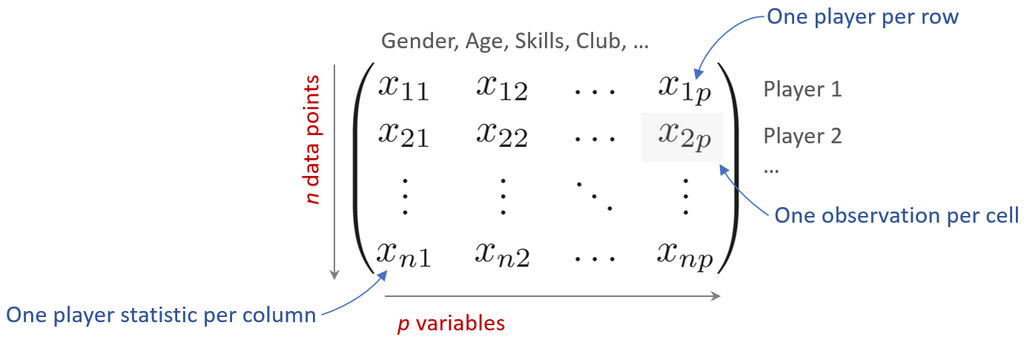

But are these these data truly tidy? In many ways they are, and yet there are various projects on GitHub that demonstrate how raw FIFA data can be transformed into a cleaner, and more usable format. However, not all problems have been corrected, and we believe that reasons behind this decision were to make FIFA data easier to understand for a ML specialist.

**Task 1:** Load `players_22.csv` data using a R code shown below. Restrict data to few selected columns using the code below. Is there anything wrong with them? If so, what is it?

```r
library(tidyverse)
library(magrittr)

#Set working directory, so you do not need to repeat long paths.
#setwd("~/Elements of AI/Labs/Data/FIFA.22.Original.Data/")
setwd("~/OneDrive/Documents/The Elements of Statistical Learning/Data/FIFA.22.Original.Data/")

data <- read_csv("players_22.csv", col_names = TRUE, num_threads = 4)
 data %<>%
  select(short_name, dob, starts_with("skill")) %>%
  slice(1:5)

data
```

```
## # A tibble: 5 × 8
##   short_name        dob        skill_moves skill_dribbling skill_curve
##   <chr>             <date>           <dbl>           <dbl>       <dbl>
## 1 L. Messi          1987-06-24           4              96          93
## 2 R. Lewandowski    1988-08-21           4              85          79
## 3 Cristiano Ronaldo 1985-02-05           5              88          81
## 4 Neymar Jr         1992-02-05           5              95          88
## 5 K. De Bruyne      1991-06-28           4              88          85
## # ℹ 3 more variables: skill_fk_accuracy <dbl>, skill_long_passing <dbl>,
## #   skill_ball_control <dbl>
```

**Task 2:** As you may guess, there are more than one way to structure the same data. The following table shows the `players_22.csv` data as above, but the rows and columns have been transposed. Are both versions equal? What do you think? Try to come up with evidence supporting your reasoning.

```
## # A tibble: 6 × 6
##   skill              `L. Messi` `R. Lewandowski` `Cristiano Ronaldo` `Neymar Jr`
##   <chr>                   <dbl>            <dbl>               <dbl>       <dbl>
## 1 skill_moves                 4                4                   5           5
## 2 skill_dribbling            96               85                  88          95
## 3 skill_curve                93               79                  81          88
## 4 skill_fk_accuracy          94               85                  84          87
## 5 skill_long_passing         91               70                  77          81
## 6 skill_ball_control         96               88                  88          95
## # ℹ 1 more variable: `K. De Bruyne` <dbl>
```

### Data Semantics

The data is the same, but the layout is different. Our vocabulary of rows and columns is simply not rich enough to describe why the two tables represent the same data. In addition to appearance, we need a way to describe the underlying semantics, or meaning, of the values displayed in the table. This can be set up as follows.

A dataset is a collection of values, where every value must belong to a **variable (column)** and an **observation (row)**. A **variable** contains all values that measure the same underlying attribute (like name, date-of-birth, height, wage) across units. An **observation** contains all values measured on the same unit (like a player, or a name) across attributes.

**Task 3:** Review a trimmed version of `players_22.csv` from above. Does it conforms to data semantics we have just outlined? If not, which key assumptions does it invalidates?

You may have noticed that *date of birth* variable — or dob — contains three values for single variable, thus conflicting an assumption that a variable has exactly one observation.

The second problem is a bit more elusive, but stays within the definition of **variable (column)**. For a given dataset, it’s usually easy to figure out what are observations and what are variables, but it is surprisingly difficult to precisely define variables and observations in general.

For example, if the columns in our data were `moves` , `dribbling` and `curve`, you would have been happy to call them variables. If the columns were `skill_moves` and `skill_dribbling`, you could treat these as two observations of a variable `skill`, but sometimes you might prefer `skill_value` and `skill_type` be variables themselves because that’s often what machine learning and plotting functions require.

We can now summarize both problems graphically:

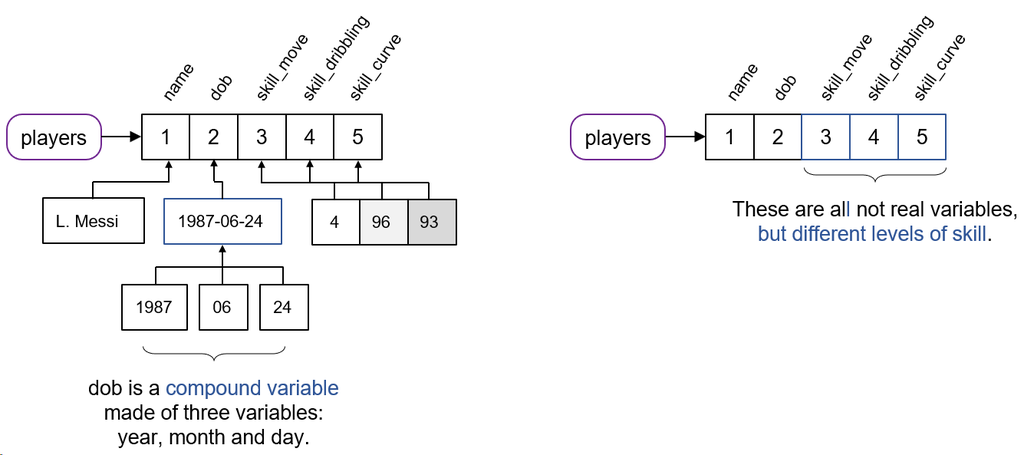

**Task 4:** Knowing what the problems are, try to work out steps needed to transform loaded data according to tidy data semantics. How many steps do you think you need?

To remedy the players data, we need to transform them according to the principles of tidy data. Tidy data is a standard way of mapping the meaning of a dataset to its structure, which is not only logical, but suitable for AI and ML. A dataset is messy or tidy depending on how rows, columns and tables are matched up with observations, variables and types. In tidy data:

1. Every column is a variable.
2. Every row is an observation.
3. Every cell is a single value.

This is Codd’s 3<sup>rd</sup> normal form, but with the constraints framed in statistical language, and the focus put on a single dataset rather than the many connected datasets common in relational databases. **Messy data** is any other arrangement.

The `players` data violate the first and the third law because:

- There are several `skill` column headers are values, not variable names.
- And in `dob`, multiple variables are stored in one column.

### Problem Identification

The process of data *tidying* involves restructuring datasets so that each variable forms a column, each observation forms a row, and each type of observational unit forms a table. This is normally done with three operations implemented in **tidyr** package which include **pivoting**, **nesting** and data **splitting**. We will now apply two of them to your data:

- **Data pivoting:** columns such as `skill_dribbling` are not variables, but represent different levels of one variable `skill`. To remedy this issue, we will transform data into the *long* format using data pivoting technique.
- **Data splitting:** `dob` column contains multiple variables stored as one column. We will remedy this issue by spitting each column into three, containing date, month and year information respectively.

### Pivoting Data with `pivot_longer()`

Let’s inspect players data once more. The data frame contains *wide* data with higher number of columns than rows. Several columns are dedicated to store information about player skills, making them informative targets for downstream analyses.

```
## # A tibble: 5 × 8
##   short_name        dob        skill_moves skill_dribbling skill_curve
##   <chr>             <date>           <dbl>           <dbl>       <dbl>
## 1 L. Messi          1987-06-24           4              96          93
## 2 R. Lewandowski    1988-08-21           4              85          79
## 3 Cristiano Ronaldo 1985-02-05           5              88          81
## 4 Neymar Jr         1992-02-05           5              95          88
## 5 K. De Bruyne      1991-06-28           4              88          85
## # ℹ 3 more variables: skill_fk_accuracy <dbl>, skill_long_passing <dbl>,
## #   skill_ball_control <dbl>
```

We will transform `skill_` data by melting their columns into two-column **key-value** pairs and appending this information to other player’s stats. The resulting table will become longer, because it will repeat `short_name` and `dob` for each `skill` key-value pair.

The process of converting wide format into long, or *vice versa*, is called **pivoting** and is shown with R code on a following figure:

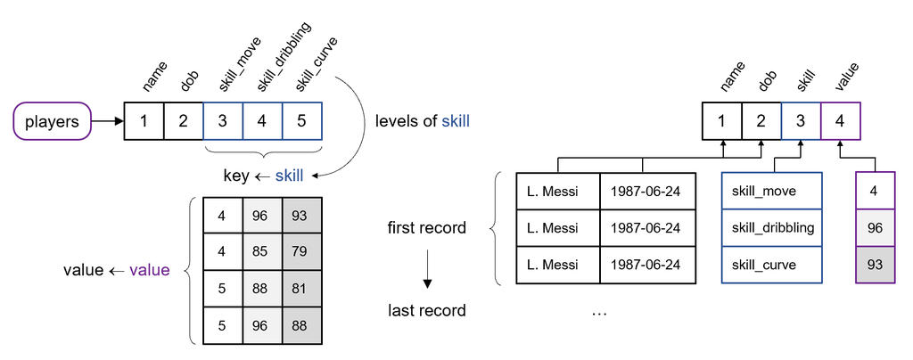

```r
pivot_longer(data,
             !c(short_name, dob), # These columns are not be touched.
             names_to = "skill",  # The key is made for all three skills...
             values_to = "value") # from which values are extracted.
```

```
## # A tibble: 30 × 4
##    short_name     dob        skill              value
##    <chr>          <date>     <chr>              <dbl>
##  1 L. Messi       1987-06-24 skill_moves            4
##  2 L. Messi       1987-06-24 skill_dribbling       96
##  3 L. Messi       1987-06-24 skill_curve           93
##  4 L. Messi       1987-06-24 skill_fk_accuracy     94
##  5 L. Messi       1987-06-24 skill_long_passing    91
##  6 L. Messi       1987-06-24 skill_ball_control    96
##  7 R. Lewandowski 1988-08-21 skill_moves            4
##  8 R. Lewandowski 1988-08-21 skill_dribbling       85
##  9 R. Lewandowski 1988-08-21 skill_curve           79
## 10 R. Lewandowski 1988-08-21 skill_fk_accuracy     85
## # ℹ 20 more rows
```

The newly transformed dataset becomes tidy, because each column represents a variable and each row represents an observation.

**Task 5:** The complementary operation to `pivot_longer()` is `pivot_wider()`. Read documentation provided by tidyverse cheat sheets and use `pivot_wider()` to recreate the original data.

### Splitting Data with `separate()`

The `separate()` function in the tidyr package allows you to split a single character column into multiple columns based on a specified separator, which can be a regular expression or numeric locations. This function is particularly useful when dealing with complex data that may have been concatenated into a single column but needs to be divided to make your data tidy. For instance, if you have a column such as `dob`, `separate()` can split it into day, month and year, making it easier to sort or filter the data.

```r
separate(data, dob, sep = "-", into = c("dob_year", "dob_month", "dob_day"))
```

```
## # A tibble: 5 × 10
##   short_name  dob_year dob_month dob_day skill_moves skill_dribbling skill_curve
##   <chr>       <chr>    <chr>     <chr>         <dbl>           <dbl>       <dbl>
## 1 L. Messi    1987     06        24                4              96          93
## 2 R. Lewando… 1988     08        21                4              85          79
## 3 Cristiano … 1985     02        05                5              88          81
## 4 Neymar Jr   1992     02        05                5              95          88
## 5 K. De Bruy… 1991     06        28                4              88          85
## # ℹ 3 more variables: skill_fk_accuracy <dbl>, skill_long_passing <dbl>,
## #   skill_ball_control <dbl>
```

**Task 6:** Similar to `pivot_wider()`, `separate()` has its counterpart `unite()`. Read the documentation and produce the most compressed form of the dataset:

```
## # A tibble: 5 × 6
##   short_name        dob        skills  skill_fk_accuracy skill_long_passing
##   <chr>             <date>     <chr>               <dbl>              <dbl>
## 1 L. Messi          1987-06-24 4-96-93                94                 91
## 2 R. Lewandowski    1988-08-21 4-85-79                85                 70
## 3 Cristiano Ronaldo 1985-02-05 5-88-81                84                 77
## 4 Neymar Jr         1992-02-05 5-95-88                87                 81
## 5 K. De Bruyne      1991-06-28 4-88-85                83                 93
## # ℹ 1 more variable: skill_ball_control <dbl>
```

### Handling Missing Values

In R, **`NA`** is used as a sentinel value to represent missing or undefined data. This placeholder can be coerced into other vector types, except raw, to maintain consistency across data structures. Functions within R, such as `na_if()` from the dplyr package, allow for the replacement of specified values with **`NA`**, which can be particularly useful in data cleaning and preparation processes. For instance, `na_if()` can be employed to convert specific values to **`NA`** when they meet certain conditions, enhancing the ability to handle missing data effectively within a dataset.

When it comes to *tidy* data, **`NA`**s are not particularly useful and you might want to consider dropping the rows containing them. To do so, `drop_na()` function can be used to remove rows with missing values, which is helpful in datasets where the absence of data is not informative.

**Task 7:** Load `player_22.csv` into R. How many rows did you get after filtering these data with `drop_na()`? Explain why you are getting this outcome.

**Task 8:** The `complete.cases()` function is a handy tool in base R for handling missing data. It returns a logical vector indicating which cases are complete, meaning they have no missing values. As such, this function is particularly useful when ensuring that datasets are free from `NA` values which can skew results. Implementation `drop_na()` using `complete.cases()` at its core.

### Footnotes

[^1]: James, Gareth, Daniela Witten, Trevor Hastie, and Robert Tibshirani. 2021. *An Introduction to Statistical Learning: With Applications in R*. 2nd ed. New York: Springer.
[^2]: Wickham, Hadley. 2019. *Advanced R*. 2nd ed. Boca Raton, FL: CRC Press.